# day4_visualization

We first demonstrate the visualization on ORA analysis.

```r
load("demo_ora.RData")
```

The following function converts gene symbols to Entrez IDs.

```r
convert_to_entrez_id = function(x, org_db = "org.Hs.eg.db") {
    if(is.matrix(x)) {
        map = cola:::guess_id_mapping(rownames(x), org_db = org_db)
        if(is.function(map)) {
            new_rn = map(rownames(x))
        } else {
            new_rn = map[rownames(x)]
        }
        l = is.na(new_rn)

        x = x[!l, , drop = FALSE]
        new_rn = new_rn[!l]

        x2 = do.call(rbind, tapply(1:nrow(x), new_rn, function(ind) {
            colMeans(x[ind, , drop = FALSE])
        }))
        return(x2)

    } else if(is.numeric(x)) {
        map = cola:::guess_id_mapping(names(x), org_db = org_db)
        x2 = x
        if(is.function(map)) {
            names(x2) = map(names(x))
        } else {
            names(x2) = map[names(x)]
        }
        x2 = x2[!is.na(names(x2))]
        x2 = tapply(x2, names(x2), mean)
        return(x2)
    } else {
        map = cola:::guess_id_mapping(x, org_db = org_db)
        if(is.function(map)) {
            x2 = map(x)
        } else {
            x2 = map[x]
        }
        x2 = x2[!is.na(x2)]
        x2 = unique(x2)
        return(x2)
    }
}
diff_gene = convert_to_entrez_id(diff_gene)
```

```
## testing org.Hs.egENSEMBL...
```

```
## testing org.Hs.egREFSEQ...
```

```
## testing org.Hs.egSYMBOL...
##   gene id might be SYMBOL (p = 0.990)
```

We perform ORA analysis with **clusterProfiler**. Note the function `enrichGO()` returns a `enrichResult` object and its slot ("`result`) contains the result table. Here we also extract the result table for future use.

Also note by default `enrichGO()` only returns significant results, so here we set `pvalueCutoff = 1` to let `enrichGO()` to return all results (both significant and insignificant).

```r
library(clusterProfiler)
library(org.Hs.eg.db)
res = enrichGO(gene = diff_gene, ont = "BP", OrgDb = org.Hs.eg.db, pvalueCutoff = 1)
tb = res@result
```

How many signfiicant GO terms (FDR < 0.05)?

```r
sum(tb$p.adjust < 0.05)
```

```
## [1] 693
```

First we make barplot for the significant terms:

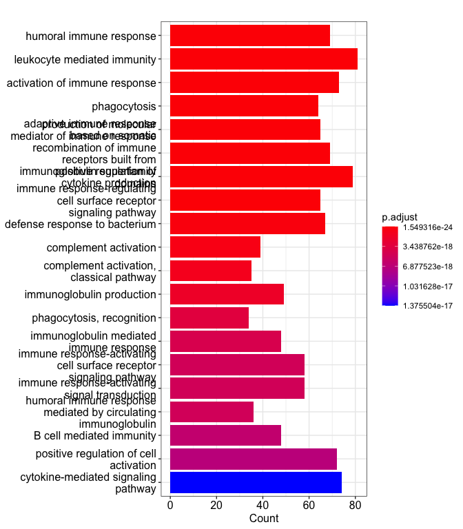

```r
library(enrichplot)
barplot(res, showCategory = 20)
```

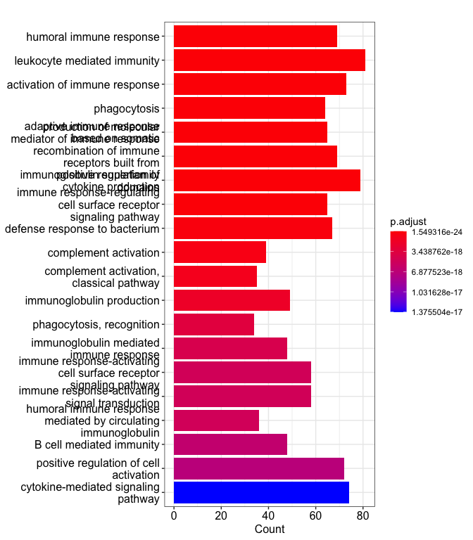

```r
barplot(res, showCategory = 20, color = "p.adjust")
```

In the result table, there are fractions of geneset gene in the diff gene list and fractions of geneset genes in the background:

```r
head(tb)
```

```
##                    ID
## GO:0006959 GO:0006959
## GO:0002443 GO:0002443
## GO:0002253 GO:0002253
## GO:0006909 GO:0006909
## GO:0002440 GO:0002440
## GO:0002460 GO:0002460
##                                                                                                                          Description
## GO:0006959                                                                                                   humoral immune response
## GO:0002443                                                                                               leukocyte mediated immunity
## GO:0002253                                                                                             activation of immune response
## GO:0006909                                                                                                              phagocytosis
## GO:0002440                                                                       production of molecular mediator of immune response
## GO:0002460 adaptive immune response based on somatic recombination of immune receptors built from immunoglobulin superfamily domains
##            GeneRatio   BgRatio       pvalue     p.adjust       qvalue
## GO:0006959    69/850 320/18903 3.018345e-28 1.549316e-24 1.240063e-24
## GO:0002443    81/850 463/18903 1.860397e-26 4.774709e-23 3.821647e-23
## GO:0002253    73/850 397/18903 2.768431e-25 4.736786e-22 3.791294e-22
## GO:0006909    64/850 314/18903 7.914723e-25 1.015657e-21 8.129254e-22
## GO:0002440    65/850 333/18903 4.220875e-24 4.333150e-21 3.468226e-21
## GO:0002460    69/850 375/18903 5.800388e-24 4.962232e-21 3.971739e-21
##                                                                                                                                                                                                                                                                                                          …
## GO:0006959                                                                        6556/729/2920/2219/4069/54209/730249/6347/3458/5967/722/725/…
## GO:0002443 2268/4843/7305/57823/729/50943/7037/3383/54209/50487/51311/1…
## GO:0002253                                          2268/7305/11119/729/50943/2219/58484/54209/3055/80381/10384/…
## GO:0006909                                                                                         2268/23221/7305/6556/2219/54209/10326/3055/1089/6347/3458/46…
## GO:0002440                                                                      50943/7037/54/57379/942/7474/8809/8013/729230/3598/54210/355…
## GO:0002460                                                              6556/729/50943/7037/3383/54209/51311/10312/57379/10384/9173/…
##            Count
## GO:0006959    69
## GO:0002443    81
## GO:0002253    73
## GO:0006909    64
## GO:0002440    65
## GO:0002460    69
```

We can calculate a “log2 fold change” which measures the relative value of fractions of geneset genes in the diff list and in the background.

The fraction is represented as strings “10/20”, so we need to parse them into R expression:

```r
gene_ratio = sapply(tb$GeneRatio, function(x) eval(parse(text = x)))
bg_ratio = sapply(tb$BgRatio, function(x) eval(parse(text = x)))
log2enrichment = log2(gene_ratio/bg_ratio)
```

It might be interesting to see the distribution of log2 enrichment.

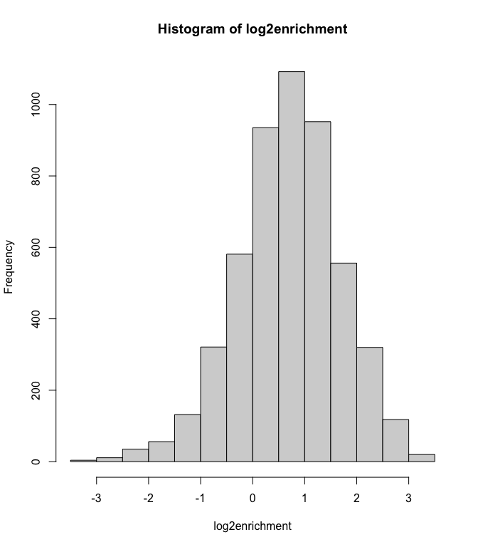

```r
hist(log2enrichment)
```

For the ease of use, `log2enrichment` is appended to both `res@result` and `tb`:

```r
res@result$log2enrichment = log2enrichment
tb$log2enrichment = log2enrichment
```

Now we can set `log2enrichment` as values on x-axis in the barplot:

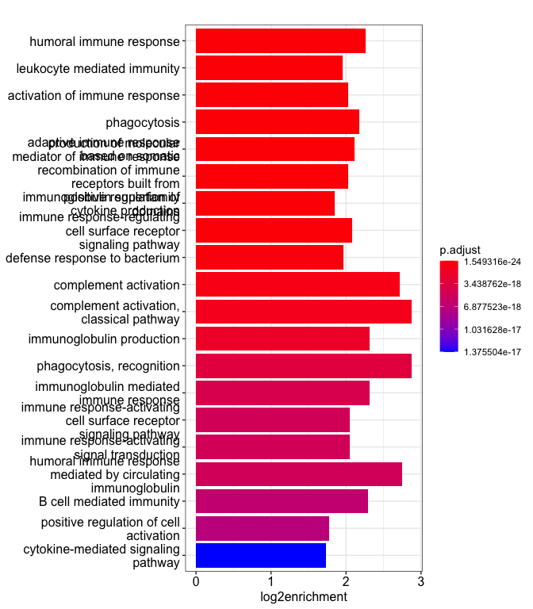

```r
barplot(res, showCategory = 20, x = "log2enrichment")
```

Making dot plot is almost the same as barplot. In dot plot, gene sets are by default reordered by values on x-axis.

Note x-axis starts from the minimal on x-axis.

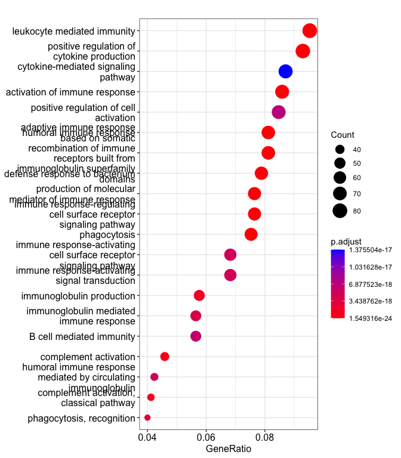

```r
dotplot(res, showCategory = 20)
```

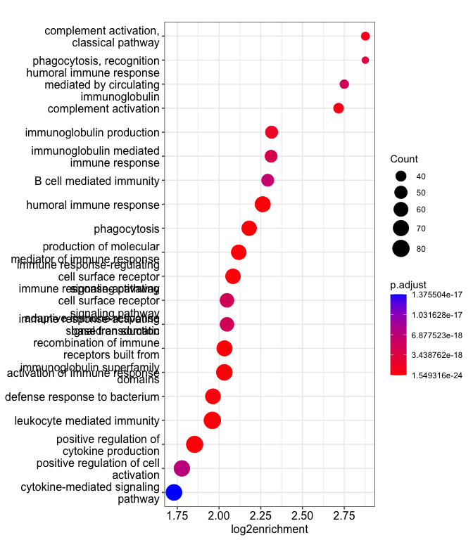

```r
dotplot(res, showCategory = 20, x = "log2enrichment")
```

Network visualization. Note by default it only shows top 5 gene sets.

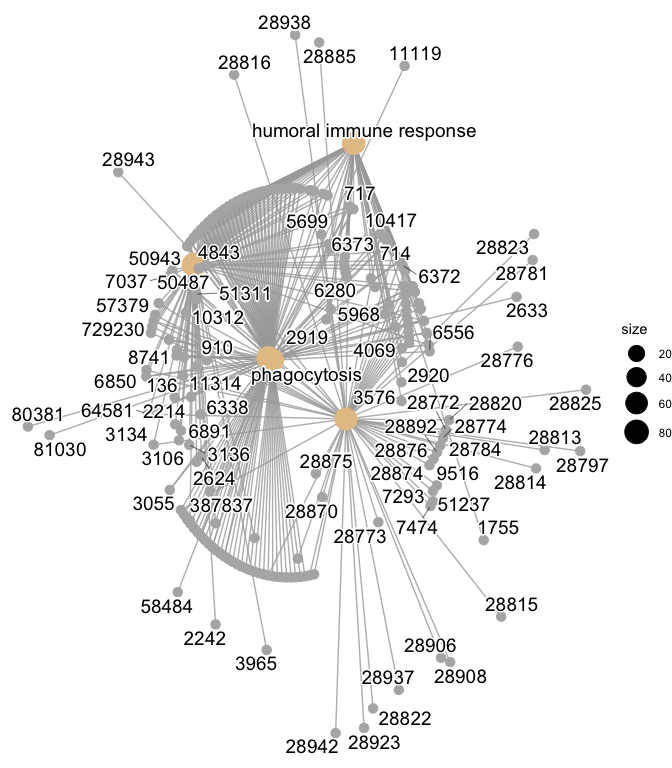

```r
cnetplot(res)
```

Heatmap-like plot to visualize gene-geneset relations:

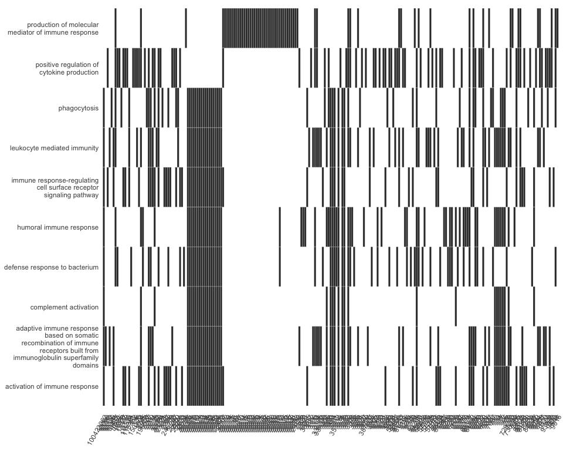

```r
heatplot(res, showCategory = 10)
```

Tree-like visualization. We first need to calculate pairwise similarity between GO terms (by default Jaccard coefficient).

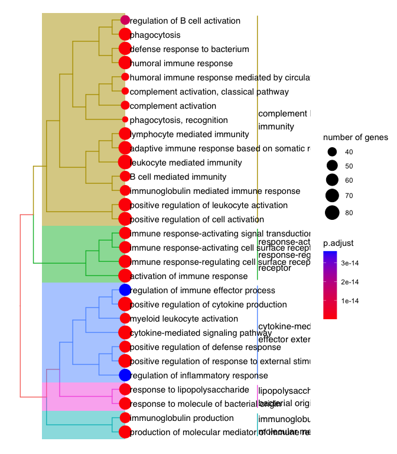

```r
res = pairwise_termsim(res)
treeplot(res)
```

Enrichment map visualization.

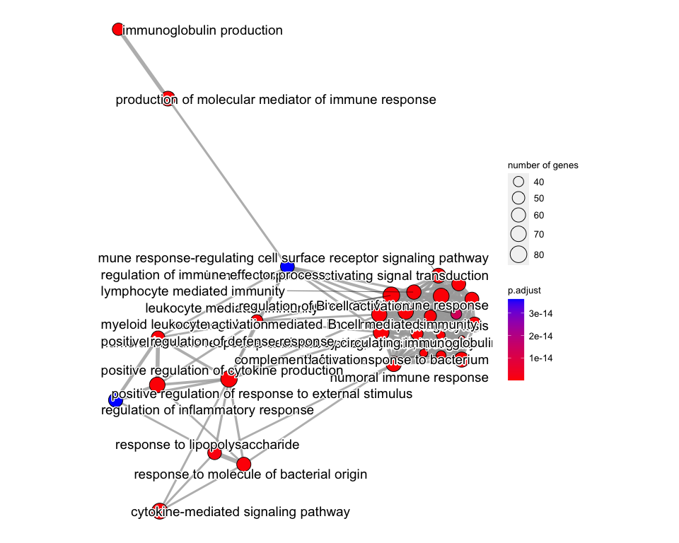

```r
emapplot(res)
```

UpSet plot.

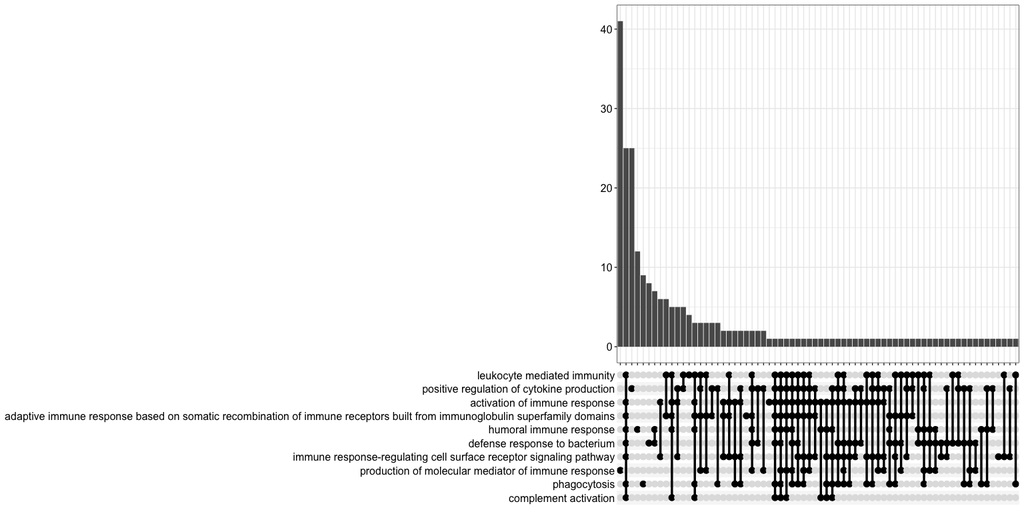

```r
upsetplot(res)
```

Volcano plot:

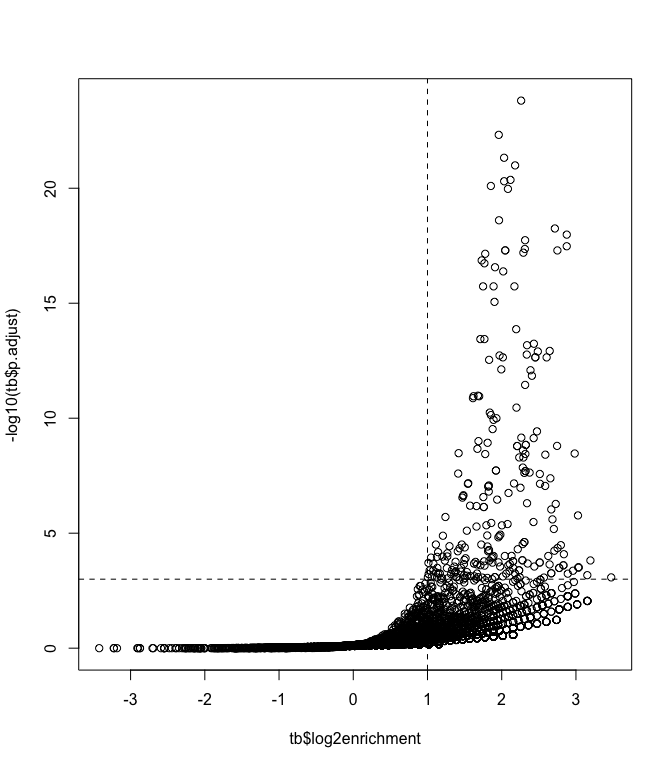

```r
plot(tb$log2enrichment, -log10(tb$p.adjust))
abline(h = 3, lty = 2)  # FDR < 0.001
abline(v = 1, lty = 2)   # log2enrichment > 1
```

Next we demonstrate visualization on GSEA results. First we perform GSEA also by **clusterProfiler**. Note here we also set `pvalueCutoff = 1` because we need the full set of results for some plots.

```r
load("gene_diff_score.RData")
gene_diff_score = sort(gene_diff_score, decreasing = TRUE)
res_gsea = gseGO(geneList=gene_diff_score, OrgDb = org.Hs.eg.db, ont = "BP", pvalueCutoff = 1)
```

Let’s check what columns are there in the result table:

```r
head(res_gsea)
```

```
##                    ID                                               Description
## GO:0007186 GO:0007186              G protein-coupled receptor signaling pathway
## GO:0098662 GO:0098662                  inorganic cation transmembrane transport
## GO:0098655 GO:0098655                            cation transmembrane transport
## GO:0030001 GO:0030001                                       metal ion transport
## GO:1902850 GO:1902850 microtubule cytoskeleton organization involved in mitosis
## GO:0098660 GO:0098660                     inorganic ion transmembrane transport
##            setSize enrichmentScore       NES       pvalue     p.adjust
## GO:0007186     471       0.3630364  1.844247 6.812215e-10 3.459243e-06
## GO:0098662     421       0.3433454  1.729040 2.168415e-07 5.505606e-04
## GO:0098655     466       0.3322436  1.685788 4.013126e-07 5.525079e-04
## GO:0030001     482       0.3262725  1.659429 4.352169e-07 5.525079e-04
## GO:1902850      69      -0.4812748 -2.214891 1.185432e-06 1.203924e-03
## GO:0098660     469       0.3243412  1.646269 1.435301e-06 1.214743e-03
##                  qvalue rank                   leading_edge
## GO:0007186 3.045419e-06 1700 tags=38%, list=25%, signal=31%
## GO:0098662 4.846979e-04 2120 tags=43%, list=31%, signal=32%
## GO:0098655 4.864121e-04 2120 tags=43%, list=31%, signal=32%
## GO:0030001 4.864121e-04 2122 tags=41%, list=31%, signal=30%
## GO:1902850 1.059901e-03 1740 tags=51%, list=26%, signal=38%
## GO:0098660 1.069425e-03 2120 tags=42%, list=31%, signal=31%
##                                                                                                                                                                                                                                                                                                          …
## GO:0007186                                                                                                         23620/26033/150/9248/23295/2151/6870/3060/3362/4544/2911/635…
## GO:0098662                                                                                                    581/8912/2906/8514/2040/150/7225/596/5371/3786/5027/6524/655…
## GO:0098655 581/8912/2906/8514/2040/150/7225/596/5371/23237/3786/5027/65…
## GO:0030001                    581/8912/2906/8514/2040/150/7225/596/5371/3786/5027/3060/652…
## GO:1902850                                                                                                                                                                                                                                                                                               …
## GO:0098660                       581/8912/2906/8514/2040/150/7225/596/5371/3786/5027/6524/655…
```

In barplot, `NES` can be used for x-axis:

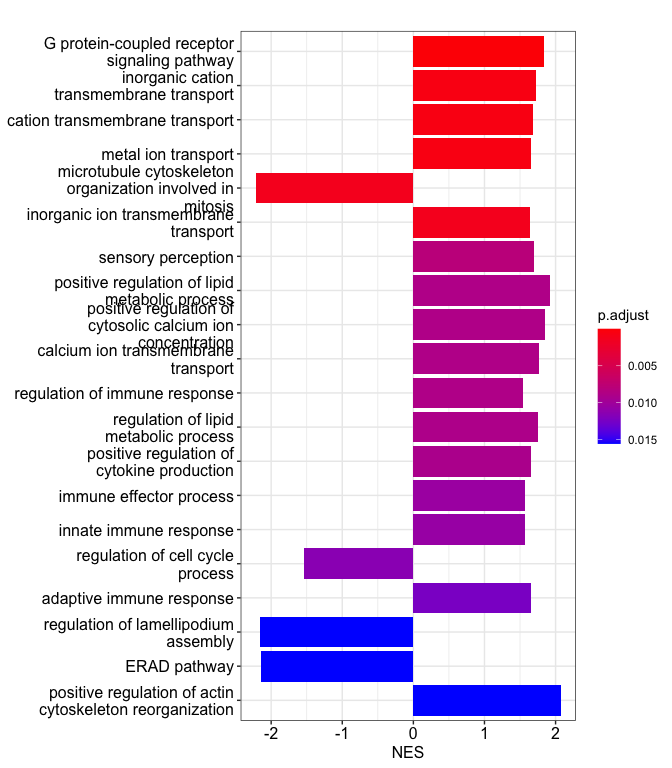

```r
enrichplot:::barplot.enrichResult(res_gsea, showCategory = 20, x = "NES")
```

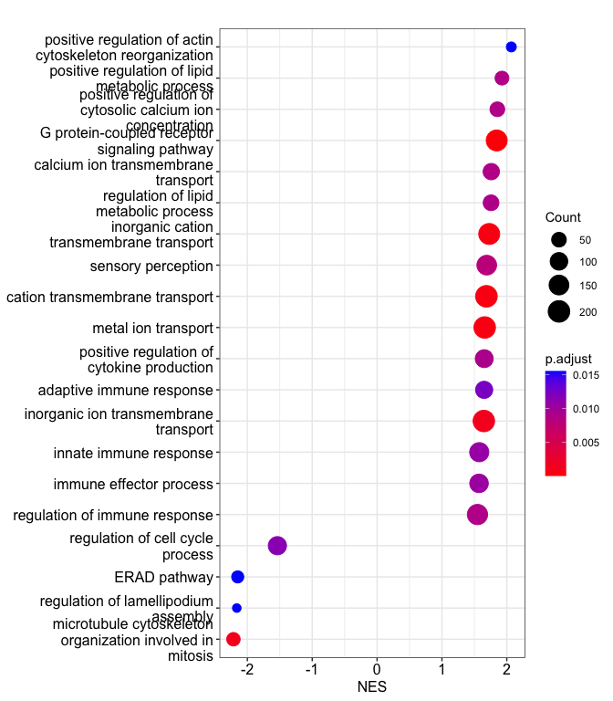

```r
dotplot(res_gsea, showCategory = 20, x = "NES")
```

Also, in Upset plot, now the distribution of gene-level statistics is added to each combination set.

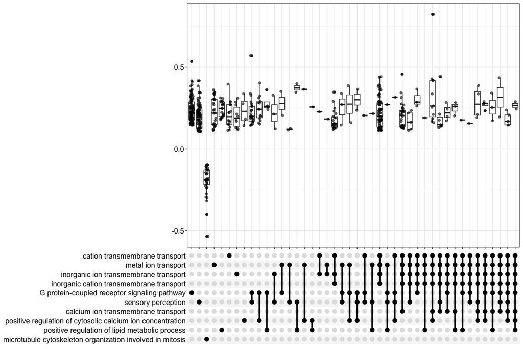

```r
upsetplot(res_gsea)
```

Ridge plot visualizes the general distribution of gene-level statistics in each set.

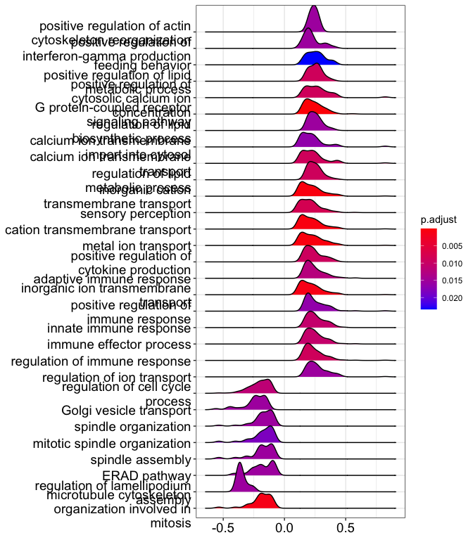

```r
ridgeplot(res_gsea)
```

And the famous GSEA plot.

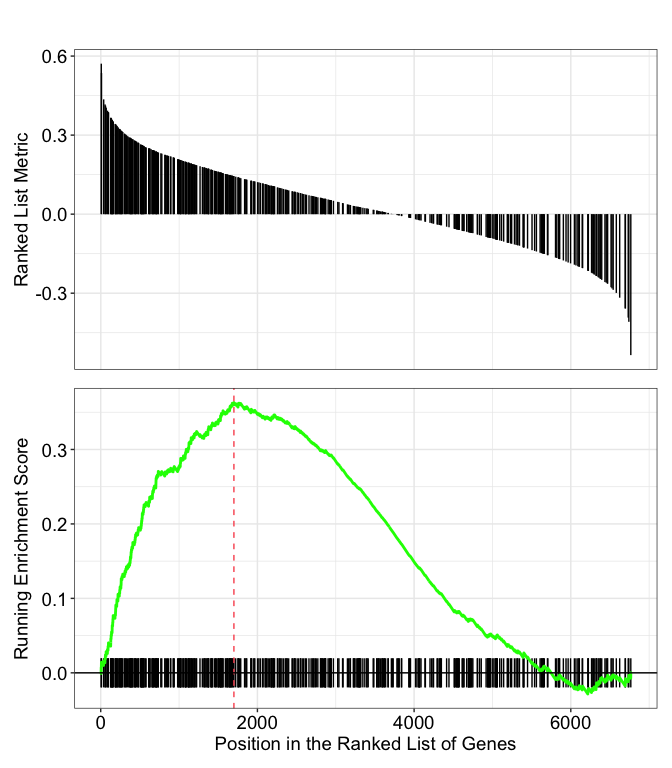

```r
gseaplot(res_gsea, geneSetID = 1)
```

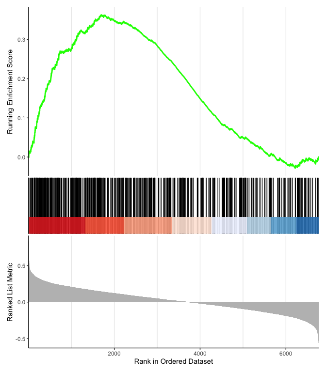

```r
gseaplot2(res_gsea, geneSetID = 1)
```

We can also compare multiple gene set in one GSEA plot. In the following plot, we visualize the most up-regulated gene set and the most down-regulated gene set.

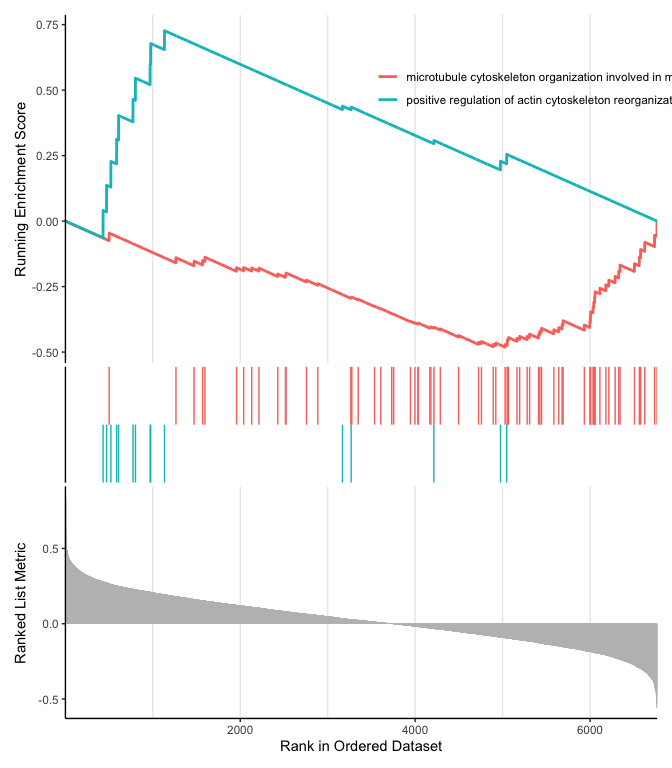

```r
ind = c(which.max(res_gsea@result$NES), which.min(res_gsea@result$NES))
gseaplot2(res_gsea, geneSetID = ind)
```

Note to make the vocalno plot. NES scores are used for x-axis:

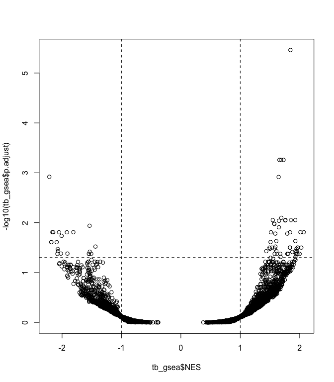

```r
tb_gsea = res_gsea@result
plot(tb_gsea$NES, -log10(tb_gsea$p.adjust))
abline(h = -log10(0.05), lty = 2)  # FDR < 0.05
abline(v = c(-1, 1), lty = 2)   # NES > 1, NES < -1
```